# Non-Seasonal Detection Approach (PVts-β)

Yonatan Tarazona Coronel

## 1. Datasets

We will use Normalized Difference Fraction Index (NDFI) to detect changes. This fractions were obtained from the Spectral Mixture Analysis physical model, see [Souza et al. (2005)](https://www.sciencedirect.com/science/article/abs/pii/S0034425705002385), through Landsat-5 TM and Landsat-8 OLI. To obtain NDFI we can use ForesToolboxRS or forestools, although it is possible to obtain it using Google Earth Engine.

## 2. Change detection steps

### **Step1**

Load the ForesToolboxRS library and other necessary libraries.

```r
suppressMessages(library(ForesToolboxRS))
suppressMessages(library(raster))
```

### **Step2**

We will detect changes from 2008 to 2018. So that, we will visualize an image from 2008 and another from 2018 to see the changes in the forest.

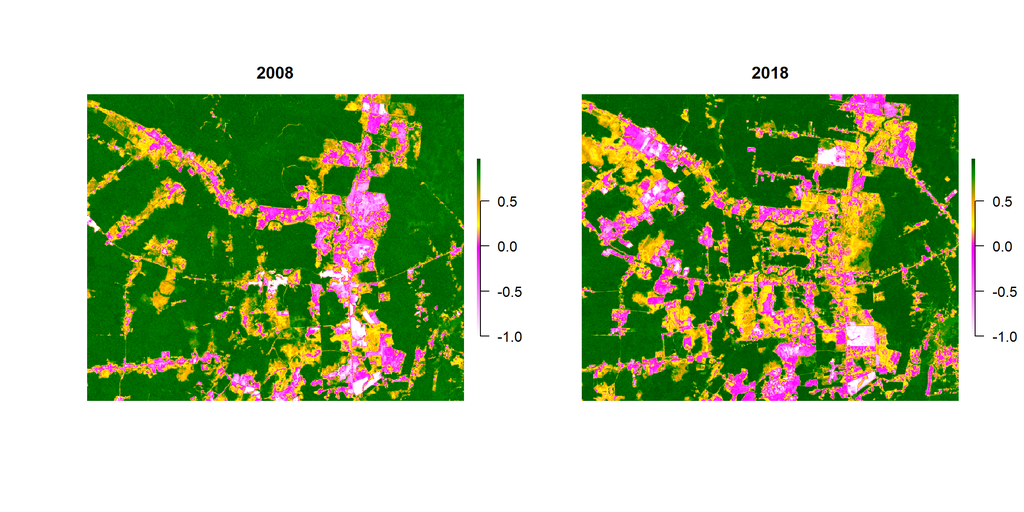

```r
path_file <- "I:/PaperSAR-Optico_Improved/CJRS/Review/Datasets/L8_232066_2000-2018_NDFI.tif"

ndfi_stack <- stack(path_file)
names(ndfi_stack) <- c("L5_232066_20000823_NDFI", "L5_232066_20010810_NDFI", "L5_232066_20020922_NDFI",
                       "L5_232066_20030715_NDFI", "L5_232066_20040802_NDFI", "L5_232066_20050720_NDFI",
                       "L5_232066_20060808_NDFI", "L5_232066_20070827_NDFI", "L5_232066_20080728_NDFI",
                       "L5_232066_20091003_NDFI", "L5_232066_20100515_NDFI", "L5_232066_20110806_NDFI",
                       "L8_232066_20130827_NDFI", "L8_232066_20140814_NDFI", "L8_232066_20150801_NDFI",
                       "L8_232066_20160803_NDFI", "L8_232066_20170806_NDFI", "L8_232066_20180926_NDFI")

# Palette
colmap <- c("#FFFFFF","#FFFCFF","#FFF9FF","#FFF7FF","#FFF4FF","#FFF2FF","#FFEFFF","#FFECFF","#FFEAFF","#FFE7FF",
            "#FFE5FF","#FFE2FF","#FFE0FF","#FFDDFF","#FFDAFF","#FFD8FF","#FFD5FF","#FFD3FF","#FFD0FF","#FFCEFF",
            "#FFCBFF","#FFC8FF","#FFC6FF","#FFC3FF","#FFC1FF","#FFBEFF","#FFBCFF","#FFB9FF","#FFB6FF","#FFB4FF",
            "#FFB1FF","#FFAFFF","#FFACFF","#FFAAFF","#FFA7FF","#FFA4FF","#FFA2FF","#FF9FFF","#FF9DFF","#FF9AFF",
            "#FF97FF","#FF95FF","#FF92FF","#FF90FF","#FF8DFF","#FF8BFF","#FF88FF","#FF85FF","#FF83FF","#FF80FF",
            "#FF7EFF","#FF7BFF","#FF79FF","#FF76FF","#FF73FF","#FF71FF","#FF6EFF","#FF6CFF","#FF69FF","#FF67FF",
            "#FF64FF","#FF61FF","#FF5FFF","#FF5CFF","#FF5AFF","#FF57FF","#FF55FF","#FF52FF","#FF4FFF","#FF4DFF",
            "#FF4AFF","#FF48FF","#FF45FF","#FF42FF","#FF40FF","#FF3DFF","#FF3BFF","#FF38FF","#FF36FF","#FF33FF",
            "#FF30FF","#FF2EFF","#FF2BFF","#FF29FF","#FF26FF","#FF24FF","#FF21FF","#FF1EFF","#FF1CFF","#FF19FF",
            "#FF17FF","#FF14FF","#FF12FF","#FF0FFF","#FF0CFF","#FF0AFF","#FF07FF","#FF05FF","#FF02FF","#FF00FF",
            "#FF00FF","#FF0AF4","#FF15E9","#FF1FDF","#FF2AD4","#FF35C9","#FF3FBF","#FF4AB4","#FF55AA","#FF5F9F",
            "#FF6A94","#FF748A","#FF7F7F","#FF8A74","#FF946A","#FF9F5F","#FFAA55","#FFB44A","#FFBF3F","#FFC935",
            "#FFD42A","#FFDF1F","#FFE915","#FFF40A","#FFFF00","#FFFF00","#FFFB00","#FFF700","#FFF300","#FFF000",
            "#FFEC00","#FFE800","#FFE400","#FFE100","#FFDD00","#FFD900","#FFD500","#FFD200","#FFCE00","#FFCA00",
            "#FFC600","#FFC300","#FFBF00","#FFBB00","#FFB700","#FFB400","#FFB000","#FFAC00","#FFA800","#FFA500",
            "#FFA500","#F7A400","#F0A300","#E8A200","#E1A200","#D9A100","#D2A000","#CA9F00","#C39F00","#BB9E00",
            "#B49D00","#AC9C00","#A59C00","#9D9B00","#969A00","#8E9900","#879900","#7F9800","#789700","#709700",
            "#699600","#619500","#5A9400","#529400","#4B9300","#439200","#349100","#2D9000","#258F00","#1E8E00",
            "#168E00","#0F8D00","#078C00","#008C00","#008C00","#008700","#008300","#007F00","#007A00","#007600",
            "#007200","#006E00","#006900","#006500","#006100","#005C00","#005800","#005400","#005000","#004C00")

# Year 2008
par(mfrow = c(1,2), oma = c(0,1, 0, 1), bty = 'n')
plot(ndfi_stack[[9]], col = colmap, axes = FALSE) # year 2008
title("2008", line = -0.5)
# Year 2018
plot(ndfi_stack[[18]], col = colmap, axes = FALSE) # year 2018
title("2018", line = -0.5)
```

### **Step3**

We can plot a time serie with breakpoint and then we will detect changes.

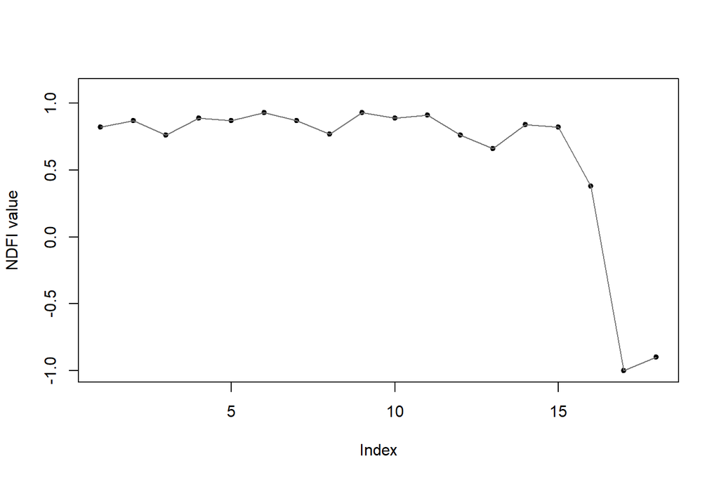

```r
ndfi_serie <- extract(ndfi_stack, cbind(377068.1248,-948511.3412))[1,] # extract with coordinates
# Plot
plot(ndfi_serie, pch = 20, xlab = "Index", ylab = "NDFI value", ylim = c(-1, 1.1))
lines(ndfi_serie, col = "gray45")
```

Before detecting a breakpoint, it is necessary to apply a smoothing to remove outliers. So, we’ll use the **smootH** function from the **ForesToolboxRS** package. The mathematical approach of this method of removing outliers implies the non-modification of the first and last values of the historical series.

If the idea is to detect changes in 2016 (position 16), then we will smooth the data only up to that position (i.e. ndfi[1:16]). This in order not to modify the value of the monitoring position.

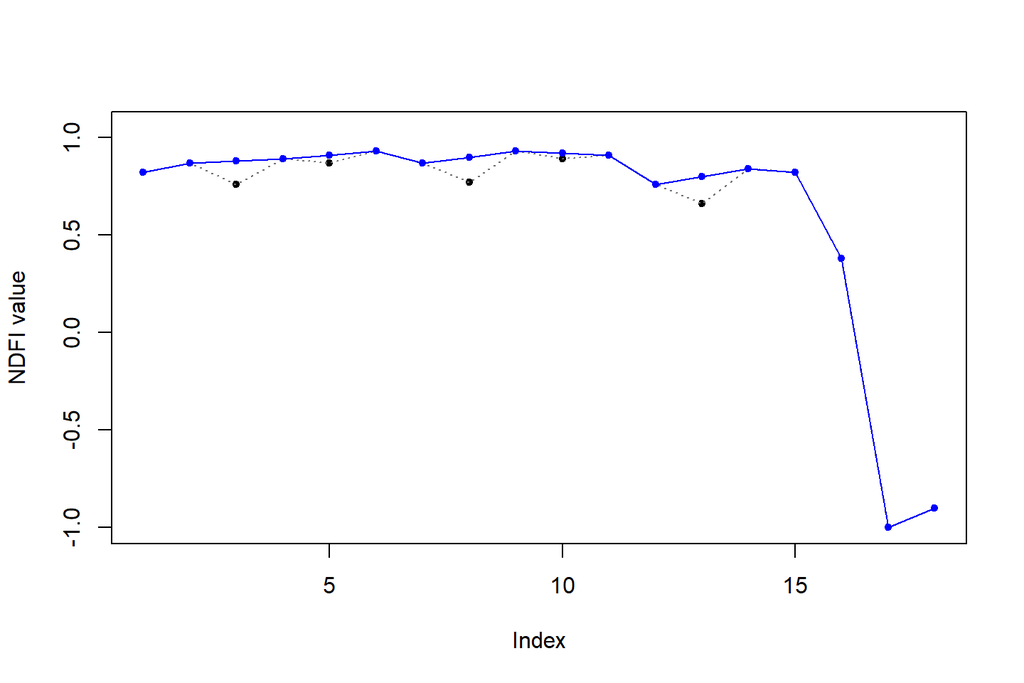

```r
ndfi_smooth <- ndfi_serie
ndfi_smooth[1:16] <- smootH(ndfi_smooth[1:16])

# Let's plot the real series
plot(ndfi_serie, pch = 20, xlab = "Index", ylab = "NDFI value", ylim = c(-1, 1.05))
lines(ndfi_serie, col = "gray45", lty = 3)
# Let's plot the smoothed series
lines(ndfi_smooth, col = "blue", ylab = "NDFI value", xlab = "Time")
points(ndfi_smooth, pch = 20, col = "blue")
```

To detect changes, either we can have a vector (using a specific index (position)) or a time series as input. We will detect changes using a vector.

Let’s use the output of the *smootH* function (**ndfi_smooth**).

Parameters: - **x**: smoothed series preferably to optimize detections. - **startm**: monitoring year, index 16 (i.e., year 2016) - **endm**: year of final monitoring, index 16 (i.e., also year 2016) - **threshold**: detection threshold (for NDFI series we will use 5). If you are using PV series, NDVI or EVI series you can use 5, 3 or 3 respectively. Please see [Tarazona et al. (2018)](https://www.sciencedirect.com/science/article/abs/pii/S1470160X18305326) for more details.

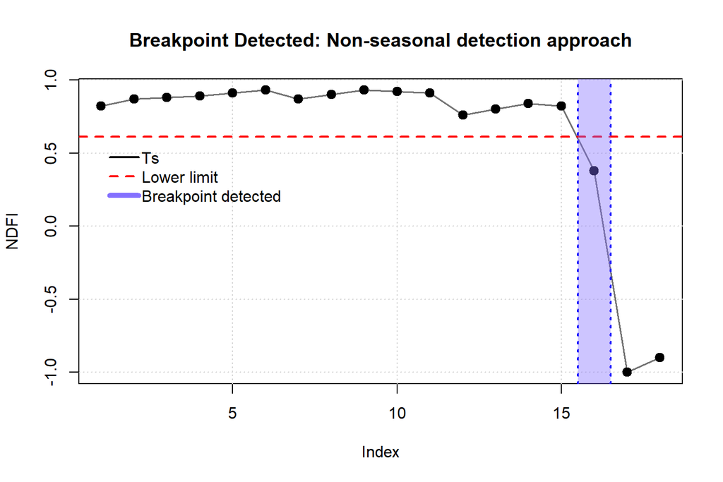

```r
# Detect changes in 2016 (position 16)
cd <- pvts(x = ndfi_smooth, startm = 16, endm = 16, threshold = 5)
plot(cd, ylab = "NDFI")
```

### **Step4**

So now we will detect changes using the **pvtsRaster ()** function. First, we need to apply a smoothing to the data. To do this we will use the **smootH ()**.

Again, if the idea is to detect changes from 2008 (position 9) to 2018 (position 18), then we will smooth the data only up to that position (i.e. only until position 9). This in order not to modify the value of the monitoring position (position 18).

```r
# Raster to matrix
ndfi_matrix <- as.matrix(ndfi_stack)
dim(ndfi_matrix) # row*col, bands
```

```
## [1] 567800     18
```

```r
# Let´s check out if our data contain NAs
any(is.na(ndfi_matrix))
```

```
## [1] FALSE
```

```r
# Applying a smoothing
ndfiSmooth <- smootH(x = ndfi_matrix[, 1:9]) # up to position 9 (year 2008)
ndfi_matrix[,1:9] <- ndfiSmooth

# *
```

Then we can detect changes with the **pvtsRaster ()** function because we are using a matrix as input. This function can read *matrix* and *raster*.

Parameters: - **x**: smoothed series preferably to optimize detections. - **startm**: monitoring year, index 9 (i.e., year 2008) - **endm**: year of final monitoring, index 18 (i.e., also year 2018) - **threshold**: detection threshold (for NDFI series we will use 5). If you are using PV series, NDVI or EVI series you can use 5, 3 or 3 respectively. Please see [Tarazona et al. (2018)](https://www.sciencedirect.com/science/article/abs/pii/S1470160X18305326) for more details.

```r
# Detecting changes with a Non-seasonal detection approach
ndfiChanges <- pvtsRaster(x = ndfi_matrix, startm = 9, endm = 18,  threshold = 5)
```

Finally, we can save this result in a raster data.

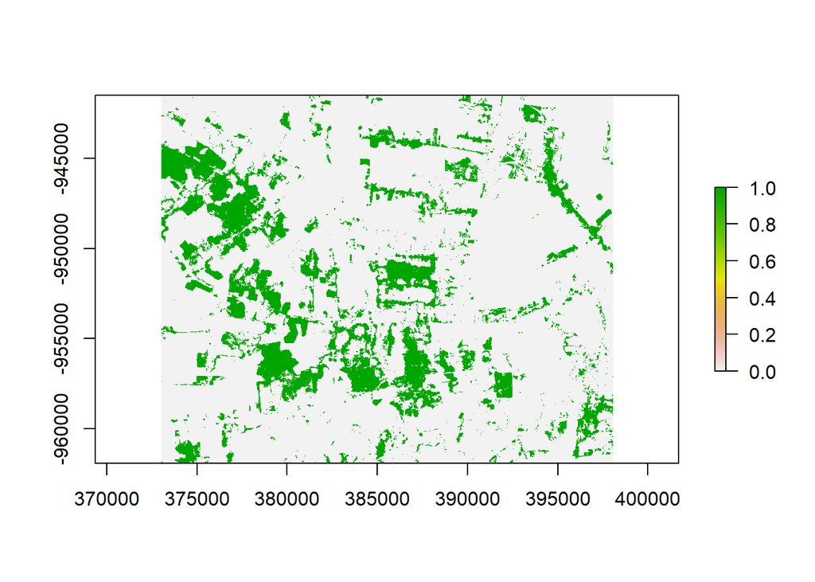

```r
rasterChanges <- raster(ndfi_stack)
values(rasterChanges) <- ndfiChanges
plot(rasterChanges)
```

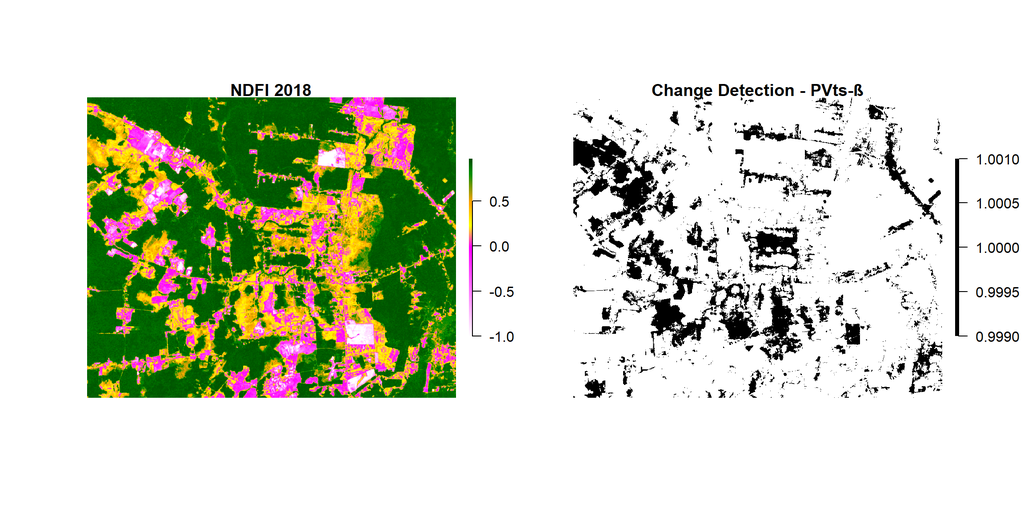

```r
rasterChanges[rasterChanges == 0] <- NA
# Visualizamos la máscara en la imagen satelital
par(mfrow = c(1,2), oma = c(0,1, 0, 2), bty = 'n')
plot(ndfi_stack[[18]], col = colmap, axes = FALSE) # year 2018
title("NDFI 2018", line = -1.5)
plot(rasterChanges, col = "black", cex.lab=0.5, cex.axis=0.3, cex.main=0.5, axes = FALSE)
title("Change Detection - PVts-β", line = -1.5)
```